# Reproducible Research: Peer Assessment 1

## Loading and preprocessing the data

For this part of the assignment, first we ensure the *activity.csv* is within the directory already unzipped. If not, we unzip it. Then we use the *read.csv* function to load the data in an object called activity. We make sure to enforce the option *stringsAsFactors=FALSE* in order to process the date column easily later on. Finally, we change the class of the date column to *date*.

```r
# unzip activity file (if not already in directory)

if(!("activity.csv" %in% list.files())) {
        unzip("activity.zip")
}

# read the data

activity <- read.csv("activity.csv", stringsAsFactors=FALSE)

# transform the date column to date format

activity$date <- as.Date(activity$date)
```

## What is mean total number of steps taken per day?

First, we calculate the total steps each day and create a new data frame. From there we can extract the mean and median values.

```r
totals <- aggregate(steps ~ date, activity, sum)
total_mean <- mean(totals$steps)
total_median <- median(totals$steps)
```

This is a basic histogram of the total number of steps taken each day during two months.

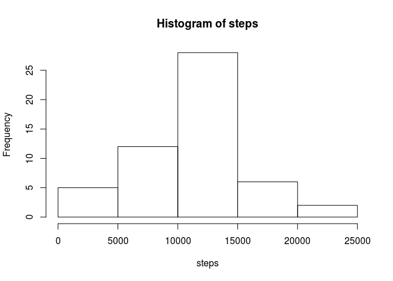

```r
with(totals, hist(steps))
```

In this dataset, the mean number of steps taken each day by this individual is `10766` and `10765` the median.

## What is the average daily activity pattern?

To answer this, we take the *aggregate* function in basic R to compute average steps every five minutes in these two months. Then we plot the result in a basic line graph.

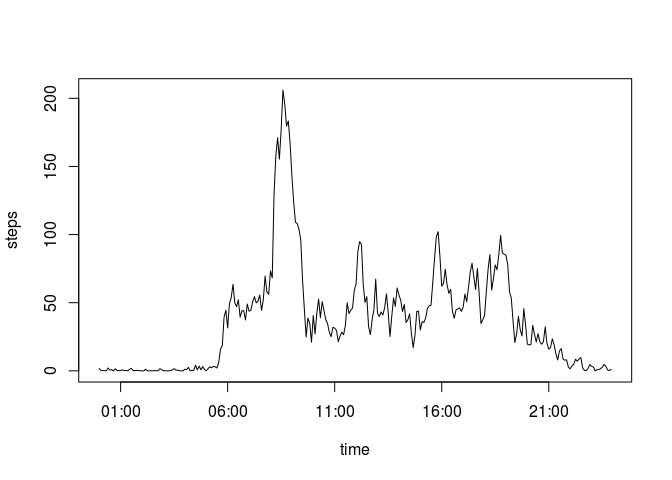

```r
# Create new data frame with the average steps every five minutes

daily_by_interval <- aggregate(steps ~ interval, activity, mean)

daily_by_interval$time <- seq(as.POSIXct("2012-10-01 00:00:00 CET"),
                              as.POSIXct("2012-10-01 23:55:00 CET"), by="5 mins")
with(daily_by_interval,
     plot(time, steps, type="l"))
```

The 5-minute interval with the average maximum value in this two months is the one between

`835` and `840`.

## Imputing missing values

The summary function gives us in its report the number of missing NAs, which in the case of the steps column account for 2,304 missing values.

```r
summary(activity)
```

```
##      steps            date               interval
##  Min.   :  0.0   Min.   :2012-10-01   Min.   :   0
##  1st Qu.:  0.0   1st Qu.:2012-10-16   1st Qu.: 589
##  Median :  0.0   Median :2012-10-31   Median :1178
##  Mean   : 37.4   Mean   :2012-10-31   Mean   :1178
##  3rd Qu.: 12.0   3rd Qu.:2012-11-15   3rd Qu.:1766
##  Max.   :806.0   Max.   :2012-11-30   Max.   :2355
##  NA's   :2304
```

To remove NAs we are going to devise an strategy where each NA is replaced by the average of the 5-minute interval where is that missing value.

To do that first we create a new data frame called *activity_full*, then we add it the column *meanSteps*, where *meanSteps* is the average number of steps in each 5-minute interval in the *daily_by_interval* object. Then we replace each NA by its corresponding mean value.

```r
# create a copy of the data frame

activity_full <- activity

# add the mean steps in each 5-minute interval

activity_full$meanSteps <- daily_by_interval$steps

# replacement of values in new data frame

activity_full[is.na(activity_full$steps), 1] <-
        activity_full[is.na(activity_full$steps), 4]
```

Finally, we are going to plot the original data frame and the one with no missing values alongside to spot the main differences.

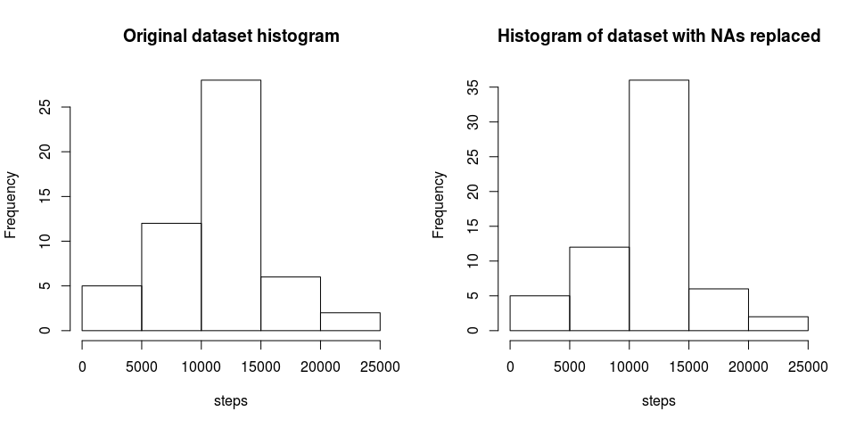

```r
# plot options
par(mfrow=c(1,2))

# histogram of original dataset

with(totals, hist(steps, main="Original dataset histogram"))

# histogram of steps in new dataset

totals2 <- aggregate(steps ~ date, activity_full, sum)
with(totals2, hist(steps, main="Histogram of dataset with NAs replaced"))
```

```r
total2_mean <- mean(totals2$steps)
total2_median <- median(totals2$steps)
```

Mean = `10766`

Median = `10766`

## Are there differences in activity patterns between weekdays and weekends?

The graph below shows a more irregular step pattern on weekends, with lots of highs and lows. The average steps between 10:00 and 20:00 are higher on weekends as well, suggesting a more active lifestyle at the end of the week.

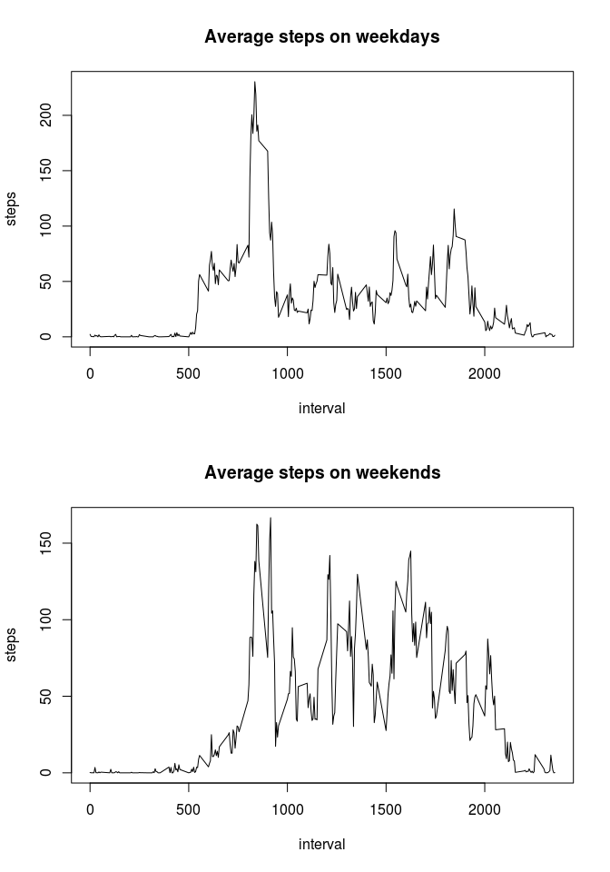

```r
# add new column with weekdays

activity_full$days <- weekdays(activity_full[,2])

# add new column with only one level: weekday

activity_full$week <- "weekday"

# insert weekends where appropriate

activity_full[activity_full$days %in% c("Saturday", "Sunday"), 6] <- "weekend"

# convert to factor

activity_full$week <- as.factor(activity_full$week)

# compute average steps by interval and type of weekday

totals3 <- with(activity_full, aggregate(steps ~ interval + week, FUN=mean))

# plot results by day of the week

par(mfrow=c(2,1))
with(totals3[totals3$week=="weekday",],
     plot(interval, steps, type="l", main="Average steps on weekdays"))
with(totals3[totals3$week=="weekend",],
     plot(interval, steps, type="l", main="Average steps on weekends"))
```